# INTRODUCCIÓN A LA MANANIPULACIÓN Y VISUALIZACIÓN DE DATOS CON R

## Gráficas: boxplot, distribuciones, barras, histogramas y entre otras

El paso más importante de hacer cualquier visualización de datos es asegurarse de que sea apropiado para su tipo de datos y que se ajuste a su propósito.

#

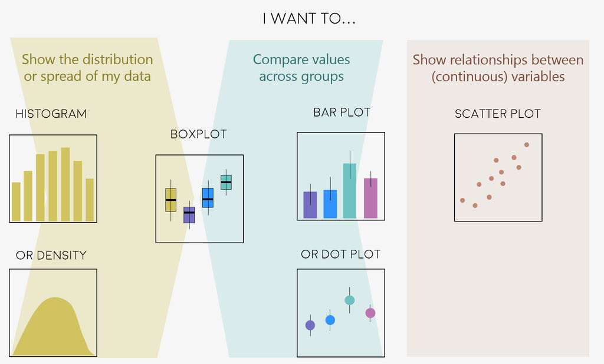

- Gráfica de barras

Primero contamos los pescados por especie que se vende en un centro de venta.

```r
especies <- unique(Fish$Species)
contar <- c()
for(i in 1:length(especies))
contar[i] <-sum(Fish$Species==especies[i])
```

Gráfico de barras para la cantidad de pescado por especies que se venden.

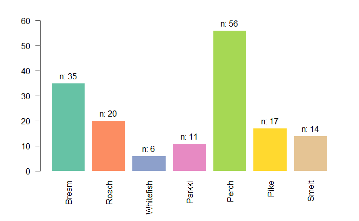

```r
barras <- barplot(contar , border=F , names.arg=especies ,
                  las=2 ,
                  col=palette("Set 2") ,
                  ylim=c(0,60) ,
                  main="" )
text(barras, contar +3, paste("n: ", contar, sep="") ,cex=1)
```

- Histogramas para visualizar la distribución de los datos

```r
hist(avocado_albany$AveragePrice, main = "Precio promedio", freq = T, col = "#B983A7")
```

[output not shown]

```r
hist(avocado_albany$AveragePrice, breaks = 40, border = F, main = "Precio promedio", freq = T, col = "#B983A7")
```

[output not shown]

Usaremos un paquete para ver comparar la distribución de la variable *AveragePrice* y la distribución normal.

```r
library(psych)
```

```r
multi.hist(x=avocado_albany$AveragePrice, dcol=c("blue", "red"), dlty = c("dotted", "solid"), main = "Precio promedio")
```

[output not shown]

- Boxplot (diagrama de cajas)

Es una representación gráfica basada en sus cuartiles, valor máximo y mínimo.

#

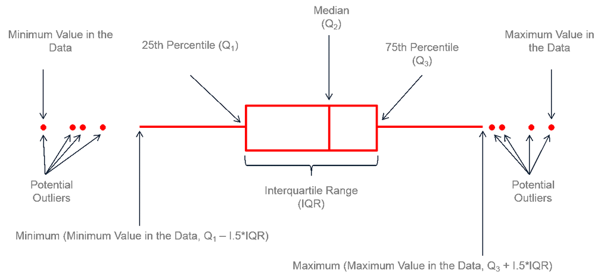

```r
boxplot(avocado_albany$AveragePrice, main ="Precio promedio", horizontal = T,  col = "#B983A7")
```

[output not shown]

- Gráfica circular

Tabla para obtener los porcentajes de acuerdo al tipo.

```r
tabla <- aggregate(Total.Volume ~ type, data = avocado_albany, FUN = sum)
x<- tabla$Total.Volume
porcentaje <- round(100*x/sum(x),1)
```

```r
library(RColorBrewer)
myPalette <- brewer.pal(8, "Set2")
```

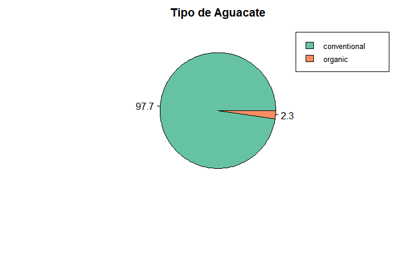

```r
pie(x, labels = porcentaje, main = "Tipo de Aguacate", col =myPalette)
legend("topright", tabla$type, cex = 0.8,
   fill = myPalette)
```

En 3D el gráfico de pastel, se usa el paquete *plotrix* usando la función *pie3d()*.

```r
library(plotrix)
```

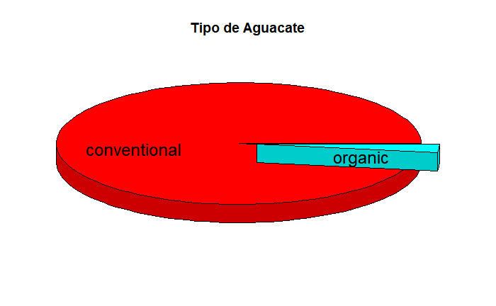

```r
pie3D(x,labels = tabla$type, radius = 2, explode = 0.1, main = "Tipo de Aguacate")
```

Vamos hacer lo mismo pero con otra base de datos con más clases.

```r
tabla1 <- aggregate(Weight ~ Species, data = Fish, FUN = sum)
x1<- tabla1$Weight
porcentaje1 <- round(100*x1/sum(x1),1)
```

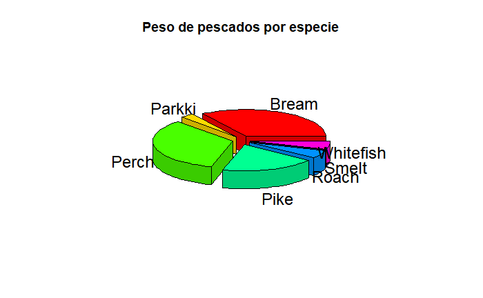

```r
pie3D(x1,labels = tabla1$Species, radius = 0.9, explode = 0.1, main = "Peso de pescados por especie")
```

- Gráfica de puntos

Utilizaremos una libreria que cuenta con base de datos que es *MASS*.

```r
library(MASS)
```

Usaremos un data frame que consiste en una colección de observaciones del Géiser Old Faithful en el Parque Nacional Yellowstone de Estados Unidos de América.

#

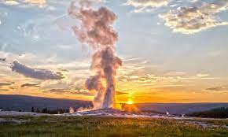

```r
head(faithful)
```

|  | eruptions | waiting |
| --- | --- | --- |
| 1 | 3.600 | 79 |
| 2 | 1.800 | 54 |
| 3 | 3.333 | 74 |
| 4 | 2.283 | 62 |
| 5 | 4.533 | 85 |
| 6 | 2.883 | 55 |

Existen dos variables en el conjunto de datos. La primera, denominada eruptions, es la duración de las erupciones del géiser. La segunda, denominada waiting, es el tiempo transcurrido hasta la siguiente erupción.

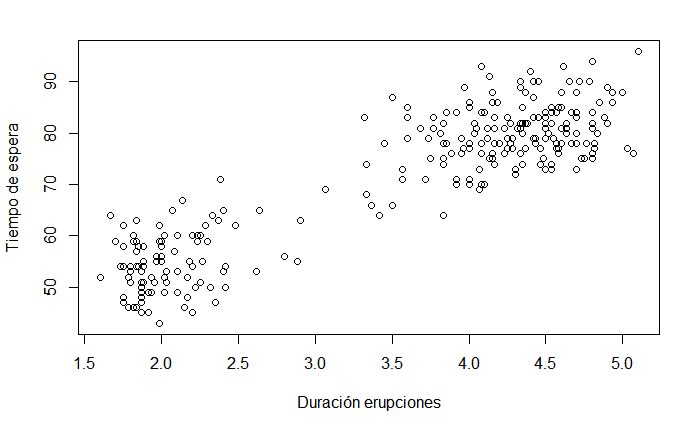

```r
duracion <- faithful$eruptions
espera <- faithful$waiting
plot(x = duracion, y = espera,
     xlab = "Duración erupciones",
     ylab = "Tiempo de espera")
```

Primero consideremos un modelo de regresión lineal

```r
modelo <- lm(espera ~ duracion)
modelo
```

```
Call:
lm(formula = espera ~ duracion)

Coefficients:
(Intercept)     duracion
      33.47        10.73
```

```r
summary(modelo)
```

```
Call:
lm(formula = espera ~ duracion)

Residuals:
     Min       1Q   Median       3Q      Max
-12.0796  -4.4831   0.2122   3.9246  15.9719

Coefficients:
            Estimate Std. Error t value Pr(>|t|)
(Intercept)  33.4744     1.1549   28.98   <2e-16 ***
duracion     10.7296     0.3148   34.09   <2e-16 ***
---
Signif. codes:
0 ‘***’ 0.001 ‘**’ 0.01 ‘*’ 0.05 ‘.’ 0.1 ‘ ’ 1

Residual standard error: 5.914 on 270 degrees of freedom
Multiple R-squared:  0.8115,    Adjusted R-squared:  0.8108
F-statistic:  1162 on 1 and 270 DF,  p-value: < 2.2e-16
```

```r
confint(modelo)
```

[output not shown]

Colocando la representación gráfica de nuestro modelo al diagrama de dispersión.

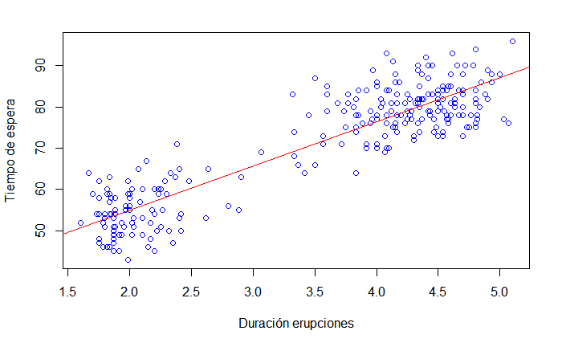

```r
plot(x = duracion, y = espera,
     xlab = "Duración erupciones",
     ylab = "Tiempo de espera",
     col = "blue")
abline(lm(espera ~ duracion), col= "red")
```

Observación: Si queremos identificar datos aítpicos, lo podemos hacer mediante el siguiente test.

```r
library(car)
```

```r
outlierTest(modelo)
```

```
No Studentized residuals with Bonferroni p < 0.05
Largest |rstudent|:
```

|  | rstudent | unadjusted p-value | Bonferroni p |
| --- | --- | --- | --- |
| 197 | 2.738019 | 0.0065935 | NA |

Un posible valor atípico esta en la posición 197.

Podemos utilizar test como el de Rosner.

Las ventajas del test son:

- Se utiliza para detectar varios valores atípicos a la vez, y
- está diseñado para evitar el problema del enmascaramiento, donde un valor atípico que tiene un valor cercano a otro puede pasar desapercibido.
- Para $n\geq 20$

```r
library(EnvStats)
```

```r
test <- rosnerTest(faithful$eruptions, k =10)
test
```

[output not shown]

[output cut: 47 more lines]

```
10 9 3.548392 1.111734 1.750     223 1.617646
   lambda.i+1 Outlier
1    3.695682   FALSE
2    3.694627   FALSE
3    3.693567   FALSE
4    3.692502   FALSE
5    3.691433   FALSE
6    3.690360   FALSE
7    3.689282   FALSE
8    3.688199   FALSE
9    3.687111   FALSE
10   3.686019   FALSE

attr(,"class")
[1] "gofOutlier"
```

La tabla que nos interesa es

```r
test$all.stats
```

| i | Mean.i | SD.i | Value | Obs.Num | R.i+1 | lambda.i+1 | Outlier |
| --- | --- | --- | --- | --- | --- | --- | --- |
| 0 | 3.487783 | 1.141371 | 1.600 | 19 | 1.653961 | 3.695682 | FALSE |
| 1 | 3.494749 | 1.137676 | 1.667 | 58 | 1.606564 | 3.694627 | FALSE |
| 2 | 3.501519 | 1.134307 | 1.700 | 115 | 1.588211 | 3.693567 | FALSE |
| 3 | 3.508216 | 1.131061 | 1.733 | 55 | 1.569514 | 3.692502 | FALSE |
| 4 | 3.514840 | 1.127937 | 1.750 | 14 | 1.564661 | 3.691433 | FALSE |
| 5 | 3.521449 | 1.124843 | 1.750 | 17 | 1.574841 | 3.690360 | FALSE |
| 6 | 3.528109 | 1.121678 | 1.750 | 22 | 1.585223 | 3.689282 | FALSE |
| 7 | 3.534819 | 1.118439 | 1.750 | 44 | 1.595813 | 3.688199 | FALSE |
| 8 | 3.541580 | 1.115125 | 1.750 | 63 | 1.606618 | 3.687111 | FALSE |
| 9 | 3.548392 | 1.111734 | 1.750 | 223 | 1.617646 | 3.686019 | FALSE |

```r
 library(mvoutlier)
```

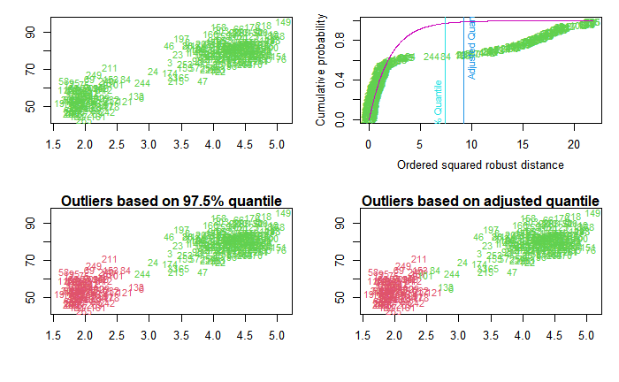

```r
y <- as.matrix(faithful)
res <- aq.plot(y)
```

La función aq.plot traza las distancias de Mahalanobis robustas al cuadrado ordenadas de las observaciones contra la función de distribución empírica de $MD^2_i$. Además, se traza la función de distribución de $chisq_p$, así como dos líneas verticales correspondientes al cuantil chisq especificado en la lista de argumentos (el valor predeterminado es 0,975) y el llamado cuantil ajustado. Se crean tres gráficos adicionales (el primero muestra los datos, el segundo muestra los valores atípicos detectados por el cuantil especificado de la distribución $chisq_p$ y el tercero muestra estos valores atípicos detectados por el cuantil ajustado).

-Matrix de correlación

Usaremos el paquete ggally para construir el correlograma.

```r
library(GGally)
```

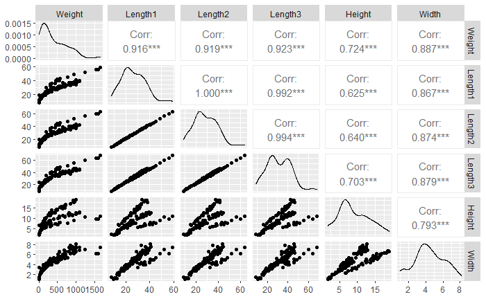

```r
ggpairs(Fish, columns = 2:7)
```

- Series de tiempo

```r
library(dygraphs)
library(xts)
library(plotly)
library(hrbrthemes)
```

https://www.kaggle.com/datasets/sumanthvrao/daily-climate-time-series-data

```r
serie_clima <- read.csv("DailyDelhiClimateTrain.csv")
```

Tenemos que revisar que las fechas tenga el formato adecuado.

```r
str(serie_clima$date)
```

```
 chr [1:1462] "2013-01-01" "2013-01-02" ...
```

No tiene le formato deseado, lo vamos a cambiar en lo que sigue

Cambiamos el formato a XTS.

```r
datos_clima <-xts(x=serie_clima$meantemp, order.by = as.Date(serie_clima$date))
```

Solo falta añadir los puntos y la gráfica final.

```r
dygraph(datos_clima) %>%
  dyOptions(drawPoints = T, pointSize = 4)
```

[interactive chart not shown]

O podemos usar un gráfico de área

```r
dygraph(datos_clima) %>%
  dyOptions(fillGraph = T)
```

[interactive chart not shown]